# Bellabeat Case Study

Alex T

2023-04-12

## About the company

Bellabeat is a high-tech company that manufactures health-focused smart products.Bellabeat has grown rapidly since its founding in 2013 and has centered itself as a tech-driven wellness company for women.

## Business task

Identify possible growth opportunities for Bellabeat smart devices and marketing strategies based on insights from other health-focused smart devices.

## The data

The data set for this case study was the FitBit Fitness Tracker Data. The data set was provided by user Mobius through the website Kaggle and was generated originally by respondents to a distributed survey via Amazon Mechanical Turk. The survey ran for 61 days starting March,12th 2016 and ending on May, 12th 2016. Thirty eligible FitBit users consented to the submission of personal tracker data, including minute-level output for physical activity, heart rate, and sleep monitoring.

## Diving into the data

Summary of the data sets:

```
## $`daily_activity `
##   total_steps    total_distance   tracker_distance logged_activities_distance
##  Min.   :    0   Min.   : 0.000   Min.   : 0.000   Min.   :0.0000
##  1st Qu.: 3790   1st Qu.: 2.620   1st Qu.: 2.620   1st Qu.:0.0000
##  Median : 7406   Median : 5.245   Median : 5.245   Median :0.0000
##  Mean   : 7638   Mean   : 5.490   Mean   : 5.475   Mean   :0.1082
##  3rd Qu.:10727   3rd Qu.: 7.713   3rd Qu.: 7.710   3rd Qu.:0.0000
##  Max.   :36019   Max.   :28.030   Max.   :28.030   Max.   :4.9421
##
##  very_active_distance moderately_active_distance light_active_distance
##  Min.   : 0.000       Min.   :0.0000             Min.   : 0.000
##  1st Qu.: 0.000       1st Qu.:0.0000             1st Qu.: 1.945
##  Median : 0.210       Median :0.2400             Median : 3.365
##  Mean   : 1.503       Mean   :0.5675             Mean   : 3.341
##  3rd Qu.: 2.053       3rd Qu.:0.8000             3rd Qu.: 4.782
##  Max.   :21.920       Max.   :6.4800             Max.   :10.710
##
##  sedentary_active_distance very_active_minutes fairly_active_minutes
##  Min.   :0.000000          Min.   :  0.00      Min.   :  0.00
##  1st Qu.:0.000000          1st Qu.:  0.00      1st Qu.:  0.00
##  Median :0.000000          Median :  4.00      Median :  6.00
##  Mean   :0.001606          Mean   : 21.16      Mean   : 13.56
##  3rd Qu.:0.000000          3rd Qu.: 32.00      3rd Qu.: 19.00
##  Max.   :0.110000          Max.   :210.00      Max.   :143.00
##
##  lightly_active_minutes sedentary_minutes    calories
##  Min.   :  0.0          Min.   :   0.0    Min.   :  52
##  1st Qu.:127.0          1st Qu.: 729.8    1st Qu.:1834
##  Median :199.0          Median :1057.5    Median :2144
##  Mean   :192.8          Mean   : 991.2    Mean   :2313
##  3rd Qu.:264.0          3rd Qu.:1229.5    3rd Qu.:2794
##  Max.   :518.0          Max.   :1440.0    Max.   :4900
##                                           NA's   :4
##
## $daily_calories
##     calories
##  Min.   :  52
##  1st Qu.:1834
##  Median :2144
##  Mean   :2313
```

[output cut: 38 more lines]

```
##  Min.   :    0
##  1st Qu.: 3790
##  Median : 7406
##  Mean   : 7638
##  3rd Qu.:10727
##  Max.   :36019
##
## $sleep
##  total_sleep_records total_minutes_asleep total_time_in_bed
##  Min.   :1.00        Min.   : 58.0        Min.   : 61.0
##  1st Qu.:1.00        1st Qu.:361.0        1st Qu.:403.8
##  Median :1.00        Median :432.5        Median :463.0
##  Mean   :1.12        Mean   :419.2        Mean   :458.5
##  3rd Qu.:1.00        3rd Qu.:490.0        3rd Qu.:526.0
##  Max.   :3.00        Max.   :796.0        Max.   :961.0
```

### Looking at the data

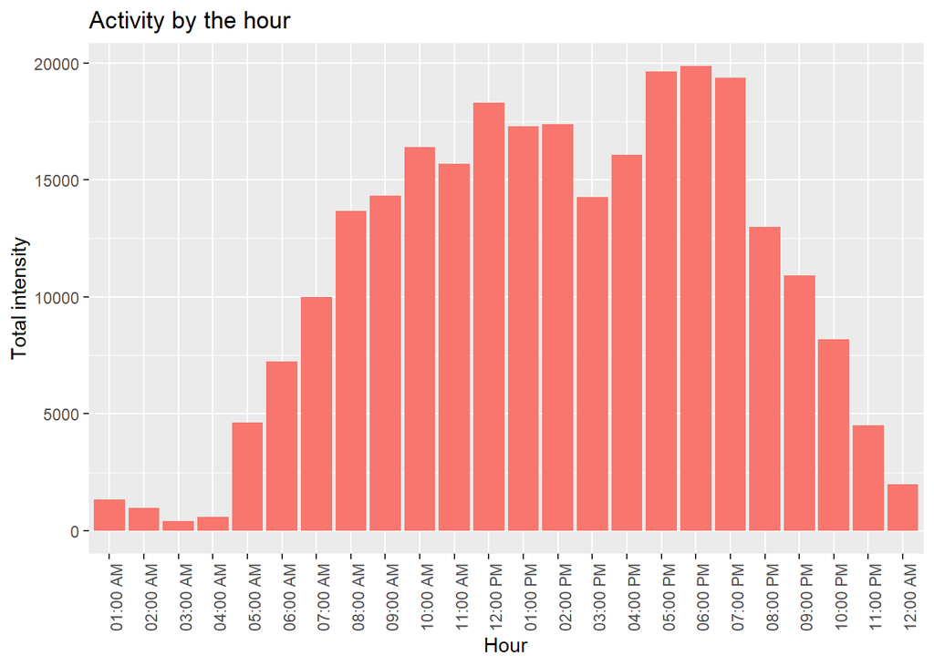

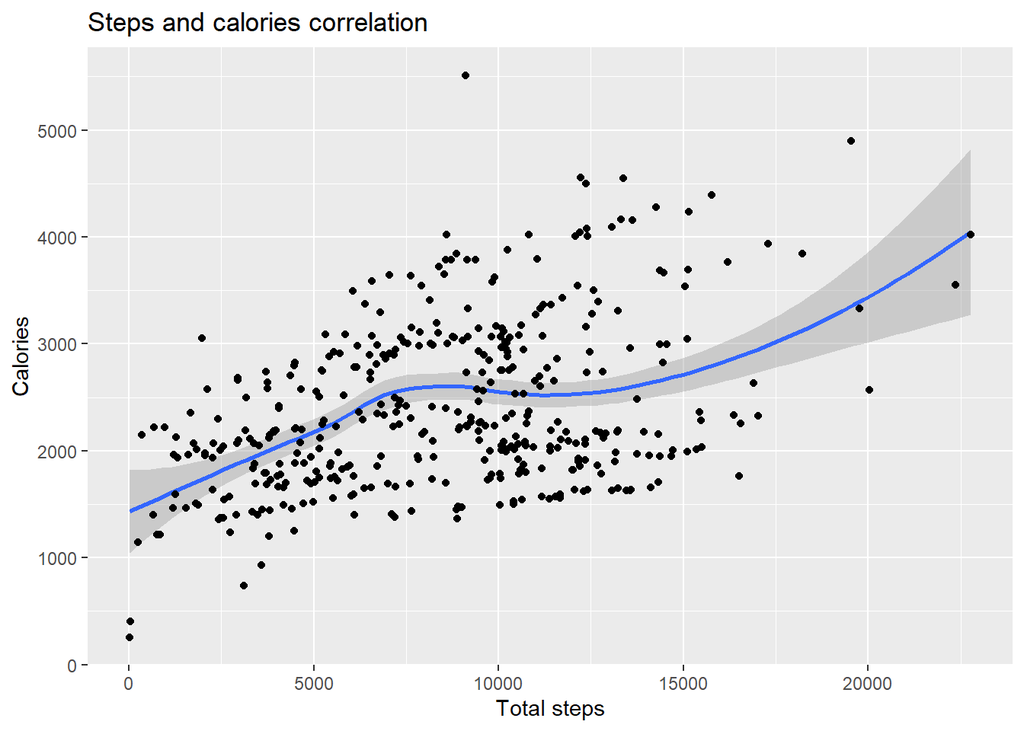

- We can see that there is a positive correlation between calories burned and steps taken. The more active you are, the more calories you burn.
- According to the CDC, intensity doesn’t really matter in this case so we can let app users know they are allowed to pace themselves with their steps throughout the day.

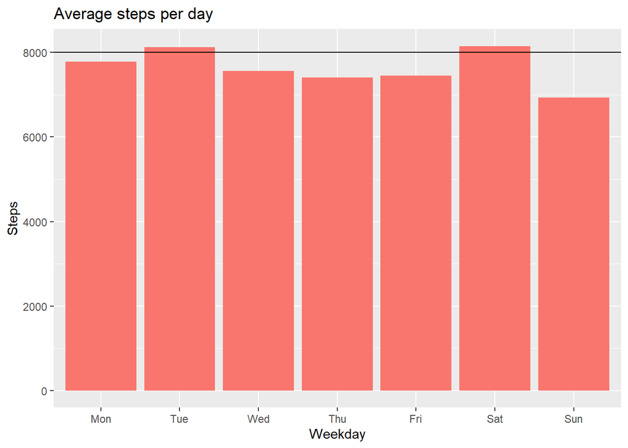

Looking at the chart tells us:

- On average, the CDC recommended step goal is only reached on Tuesday & Saturday
  - While 8000 steps are good, 10,000 or 12,000 steps daily would be ideal per the CDC.
- The lowest average steps on Sunday.
  - Could be because people are mainly relaxing and getting ready for the work week.

## Recommendations

### Recommendations for future analysis

- A more detailed and diverse data set would be extremely beneficial to gathering more accurate insights. Future data should include the user’s sex, height, and age.it could also be helpful to include the type of work they do categorized by activity level: sedentary, moderate etc.
- The data should also feature a larger number of participants with varying characteristics such as age and sex.
- Having app users answer various survey questions after consistently using the app for at least 1 month would be very helpful with gathering insight for future analysis.
  - Survey questions could be about the app itself or anything pertaining to exercise.

### Recommendations for Bellabeat app

- The app should give users the ability to turn on health notifications/tips that are separate from the standard in-app notifications. Notifications could be from the CDC or any reputable health organization.
  - Notifications could be sent daily, weekly, or even dependent on particular situations(E.g: step counter approaching the recommended 8000, sleeping less than the recommended hours). The goal here is to inform users on why it may be important to hit certain numbers.
  - Tips and techniques tailored to an individual’s stats should also be sent out periodically.
  - The membership program may have to be reworked in order to prevent the free insights from compromising on the paid insights.Analysis on the membership program would be needed to discuss further.
- Using the app consistently should allow users to receive discount on other Bellabeat products.

### General recommendations

- Having ads play during the busiest workout times(5PM - 7PM) could possibly be beneficial to getting more people to use the Bellabeat app/products if the busy trend is reflective of other people that workout.
  - Radio ads for those getting off work or on the way to the gym. (Spotify included)
  - Television ads for gyms that have accessible TVs.

## Conclusion

While the current data will suffice at the moment, more data will be needed in order to give more detailed insight and to make bigger business decisions with confidence. A survey involving current Bellabeat customers would be the best way to springboard any further phases of analysis.

## Appendix

- [CDC Recommended sleep](https://www.cdc.gov/sleep/about_sleep/how_much_sleep.html)
- [CDC Steps per day](https://www.cdc.gov/media/releases/2020/p0324-daily-step-count.html#:~:text=Taking%2012%2C000%20steps%20per%20day,compared%20with%20taking%204%2C000%20steps)